# **A quantitative analysis of classical denoising methods**

**Méthode GCV pour trouver le meilleur lambda**

```python
# --- Calcul du critère GCV ---
def compute_gcv(noisy_image, D, lmbda):
    #transformation de l'image bruitée dans le domaine de Fourier
    noisy_image = noisy_image
    Y = np.fft.fft2(noisy_image)
    #le filtre Tikhonov dans le domaine fréquentiel
    #On a : x_hat = D* / (|D|^2 + λ) * Y, donc le résidu en fréquence est
    #r = (λ / (|D|^2+λ)) * Y
    filter_factor = lmbda / (np.abs(D)**2 + lmbda)
    residual_fft = filter_factor * Y
    #calcul de la norme L2 du résidu (via la transformée inverse)
    residual = np.fft.ifft2(residual_fft)
    residual_norm_sq = np.sum(np.abs(residual)**2)
    #le terme trace(I - A(λ)) s'exprime ici par : somme(λ/(|D|^2+λ))
    trace_term = np.sum(filter_factor)
    N = noisy_image.size  # nombre total de pixels
    #critère GCV
    gcv = residual_norm_sq / ((trace_term / N) ** 2)
    return gcv

# --- Recherche du lambda optimal par GCV ---
def find_optimal_lambda_gcv(noisy_image, D, lambda_values):
    gcv_values = np.array([compute_gcv(noisy_image, D, lmbda) for lmbda in lambda_values])
    optimal_index = np.argmin(gcv_values)
    optimal_lambda = lambda_values[optimal_index]
    return optimal_lambda, gcv_values
```

```
Lambda optimal trouvé par GCV : 0.0002811768697974231
```

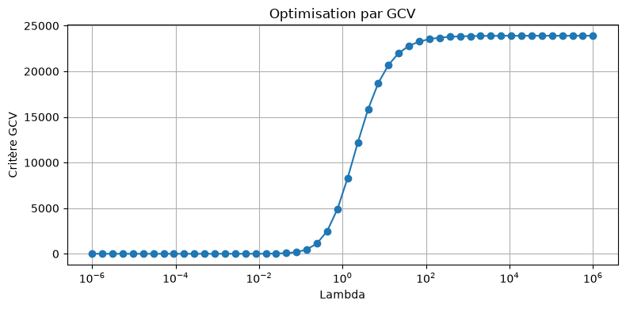

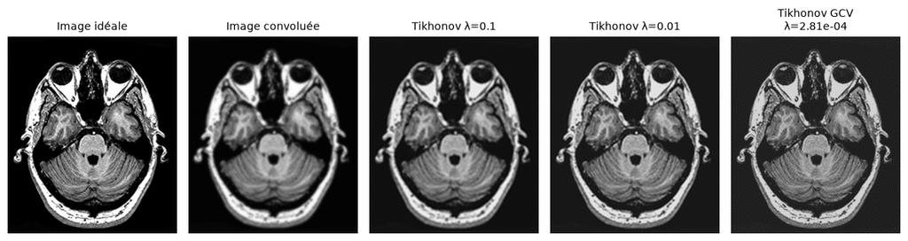

```python
lambda_values = np.logspace(-6, 6, 50)
optimal_lambda, gcv_values = find_optimal_lambda_gcv(mri_noised, D, lambda_values)
print("Lambda optimal trouvé par GCV :", optimal_lambda)

estimation_optimal = tikhonov(mri_noised, D, optimal_lambda)
# --- Figure du GCV ---
plt.figure(figsize=(8, 4))
plt.semilogx(lambda_values, gcv_values, marker='o')
plt.xlabel("Lambda")
plt.ylabel("Critère GCV")
plt.title("Optimisation par GCV")
plt.grid(True)
plt.tight_layout()
plt.show()

# --- Figure des images ---
plt.figure(figsize=(12, 6))

# Image idéale
plt.subplot(1, 5, 1)
plt.imshow(mri, cmap='gray')
plt.title("Image idéale", fontsize=10)
plt.axis('off')

# Image convoluée
plt.subplot(1, 5, 2)
plt.imshow(mri_noised, cmap='gray')
plt.title("Image convoluée", fontsize=10)
plt.axis('off')

# Déconvolution Tikhonov lambda = 0.1
plt.subplot(1, 5, 3)
plt.imshow(i_hat, cmap='gray')
plt.title("Tikhonov λ=0.1", fontsize=10)
plt.axis('off')

# Déconvolution Tikhonov lambda = 0.01
plt.subplot(1, 5, 4)
plt.imshow(i_hat2, cmap='gray')
plt.title("Tikhonov λ=0.01", fontsize=10)
plt.axis('off')

# Déconvolution Tikhonov avec GCV
plt.subplot(1, 5, 5)
plt.imshow(estimation_optimal, cmap='gray')
plt.title(f"Tikhonov GCV\nλ={optimal_lambda:.2e}", fontsize=10)
plt.axis('off')

plt.tight_layout()
plt.show()
```

**Méthode ML (max de vraisemblance) pour trouver le meilleur lambda**

```python
def compute_evidence(noisy_image, D, lmbda):
    noisy_image = noisy_image
    Y = np.fft.fft2(noisy_image)
    D_T_D = np.abs(D)**2
    # La fonction d'évidence (à une constante additive près)
    evidence = 0.5 * np.sum(np.log(D_T_D + lmbda)) + 0.5 * np.sum(np.abs(Y)**2 / (D_T_D + lmbda))
    return evidence
```

```python
def find_optimal_lambda_ml(noisy_image, D, lambda_values):
    evidences = np.array([compute_evidence(noisy_image, D, lmbda) for lmbda in lambda_values])
    optimal_index = np.argmin(evidences)
    optimal_lambda = lambda_values[optimal_index]
    return optimal_lambda, evidences
```

```
Lambda optimal trouvé par maximum de vraisemblance : 0.0001
```

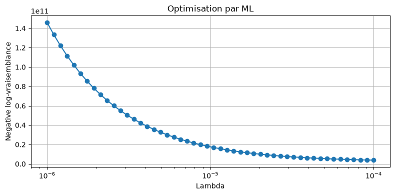

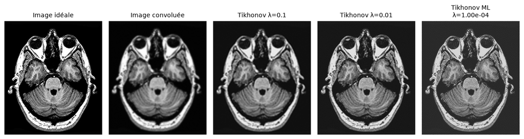

```python
lambda_values = np.logspace(-6, -4, 50)
optimal_lambda, evidences = find_optimal_lambda_ml(mri_noised, D, lambda_values)
print("Lambda optimal trouvé par maximum de vraisemblance :", optimal_lambda)
estimation_ml = tikhonov(mri_noised, D, optimal_lambda)

# --- Figure du GCV ---
plt.figure(figsize=(8, 4))
plt.semilogx(lambda_values, evidences, marker='o')
plt.xlabel("Lambda")
plt.ylabel("Negative log-vraisemblance")
plt.title("Optimisation par ML")
plt.grid(True)
plt.tight_layout()
plt.show()

# --- Figure des images ---
plt.figure(figsize=(12, 6))

# Image idéale
plt.subplot(1, 5, 1)
plt.imshow(mri, cmap='gray')
plt.title("Image idéale", fontsize=10)
plt.axis('off')

# Image convoluée
plt.subplot(1, 5, 2)
plt.imshow(mri_noised, cmap='gray')
plt.title("Image convoluée", fontsize=10)
plt.axis('off')

# Déconvolution Tikhonov lambda = 0.1
plt.subplot(1, 5, 3)
plt.imshow(i_hat, cmap='gray')
plt.title("Tikhonov λ=0.1", fontsize=10)
plt.axis('off')

# Déconvolution Tikhonov lambda = 0.01
plt.subplot(1, 5, 4)
plt.imshow(i_hat2, cmap='gray')
plt.title("Tikhonov λ=0.01", fontsize=10)
plt.axis('off')

# Déconvolution Tikhonov avec GCV
plt.subplot(1, 5, 5)
plt.imshow(estimation_ml, cmap='gray')
plt.title(f"Tikhonov ML\nλ={optimal_lambda:.2e}", fontsize=10)
plt.axis('off')

plt.tight_layout()
plt.show()
```

**Essayons avec un filtre h(x,y) et un RSB différents.**

```python
mri = cv2.imread("mri.jpg", cv2.IMREAD_GRAYSCALE)
#convertir en float64
mri = mri.astype(np.float64)
mri = mri / 255.0
```

```
Variance du bruit 0.001255645060366653
```

```
(np.float64(-0.5), np.float64(377.5), np.float64(439.5), np.float64(-0.5))
```

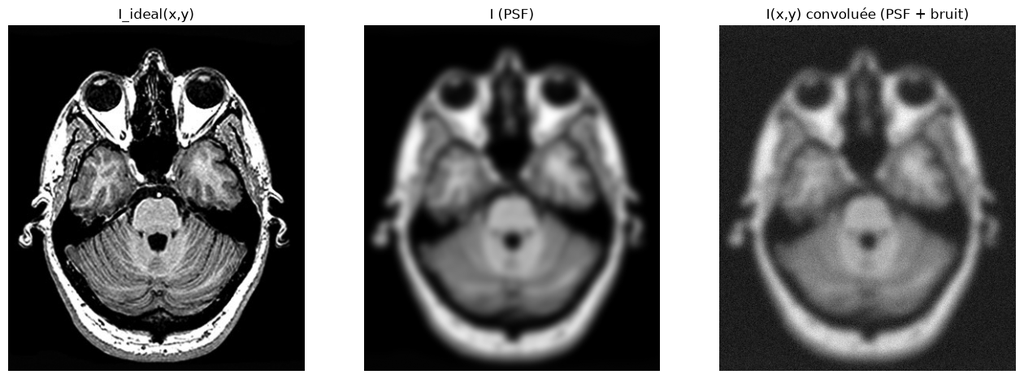

```python
#Créer un filtre gaussien 31x31 avec sigma = 5
h = np.zeros((31, 31))
h[15, 15] = 1
h = gaussian_filter(h, sigma=5)

#Normalisation (somme = 1)
h /= h.sum()


#Padding de h pour qu'il fasse la même taille que x
h_pad = np.pad(h, ((0, mri.shape[0]-h.shape[0]),(0,mri.shape[1]-h.shape[1])), 'constant')

#Roll de h (circshift)
h_roll = np.roll(h_pad, -h.shape[0]//2, axis=0)
h_roll = np.roll(h_roll, -h.shape[1]//2, axis=1)

#H = np.fft.fft2(h_roll)

#Valeurs propres de HBCCB
D = np.fft.fft2(h_roll, s=mri.shape)

X = np.fft.fft2(mri)

conv_X = D * X

mri_conv = np.real(np.fft.ifft2(conv_X))

#Bruiter

mri_noised, noise_variance = gen_noised(mri_conv,20)
print("Variance du bruit", noise_variance)

plt.figure(figsize=(16, 8))
plt.subplot(1, 3, 1)
plt.imshow(mri, cmap='gray')
plt.title("I_ideal(x,y)")
plt.axis("off")

plt.subplot(1, 3, 2)
plt.imshow(mri_conv, cmap='gray')
plt.title("I (PSF)")
plt.axis("off")

plt.subplot(1, 3, 3)
plt.imshow(mri_noised, cmap='gray')
plt.title("I(x,y) convoluée (PSF + bruit)")
plt.axis("off")
```

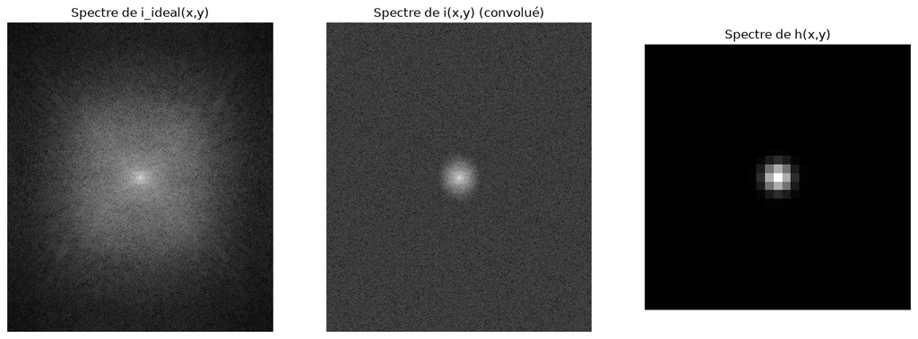

```python
#Visualiser la transformée de Fourier de i_ideal(x,y), de i(x,y) et de h(x,y)
i_ideal_spectrum = np.log(1 + np.abs(np.fft.fftshift(np.fft.fft2(mri))))
i_spectrum = np.log(1 + np.abs(np.fft.fftshift(np.fft.fft2(mri_noised))))
h_spectrum = np.log(1 + np.abs(np.fft.fftshift(np.fft.fft2(h))))
plt.figure(figsize=(16, 8))
#afficher les 3 images dans la figure
plt.subplot(1, 3, 1)
plt.imshow(i_ideal_spectrum, cmap='gray')
plt.title("Spectre de i_ideal(x,y)")
plt.axis("off")

plt.subplot(1, 3, 2)
plt.imshow(i_spectrum, cmap='gray')
plt.title("Spectre de i(x,y) (convolué)")
plt.axis("off")

plt.subplot(1, 3, 3)
plt.imshow(h_spectrum, cmap='gray')
plt.title("Spectre de h(x,y)")
plt.axis("off")

plt.show()
```

```
(np.float64(-0.5), np.float64(377.5), np.float64(439.5), np.float64(-0.5))
```

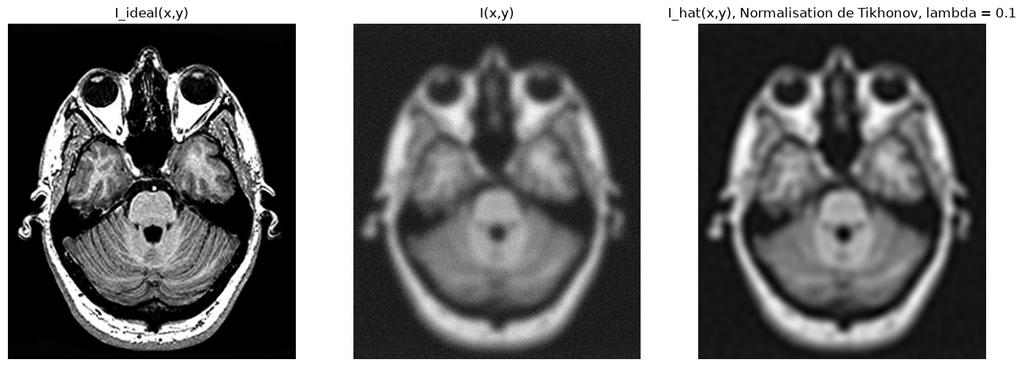

```python
i_hat = tikhonov(mri_noised, D, lmbda=0.1)
plt.figure(figsize=(16, 8))

plt.subplot(1, 3, 1)
plt.imshow(mri, cmap='gray')
plt.title("I_ideal(x,y)")
plt.axis("off")

plt.subplot(1, 3, 2)
plt.imshow(mri_noised, cmap='gray')
plt.title("I(x,y)")
plt.axis("off")

plt.subplot(1, 3, 3)
plt.imshow(i_hat, cmap='gray')
plt.title("I_hat(x,y), Normalisation de Tikhonov, lambda = 0.1")
plt.axis("off")
```

```
(np.float64(-0.5), np.float64(377.5), np.float64(439.5), np.float64(-0.5))
```

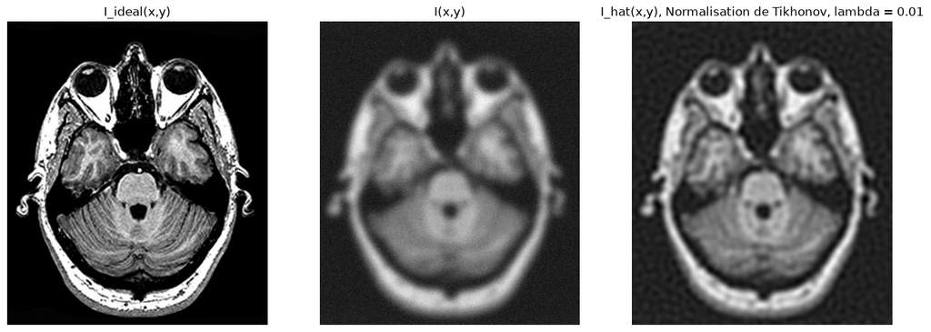

```python
i_hat2 = tikhonov(mri_noised, D, lmbda=0.01)
plt.figure(figsize=(16, 8))

plt.subplot(1, 3, 1)
plt.imshow(mri, cmap='gray')
plt.title("I_ideal(x,y)")
plt.axis("off")

plt.subplot(1, 3, 2)
plt.imshow(mri_noised, cmap='gray')
plt.title("I(x,y)")
plt.axis("off")

plt.subplot(1, 3, 3)
plt.imshow(i_hat2, cmap='gray')
plt.title("I_hat(x,y), Normalisation de Tikhonov, lambda = 0.01")
plt.axis("off")
```

```
Lambda optimal trouvé par GCV : 0.0015264179671752333
```

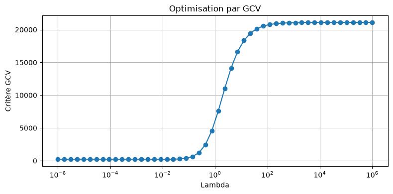

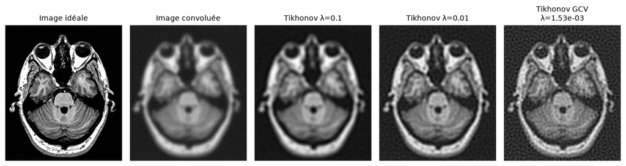

```python
lambda_values = np.logspace(-6, 6, 50)
optimal_lambda, gcv_values = find_optimal_lambda_gcv(mri_noised, D, lambda_values)
print("Lambda optimal trouvé par GCV :", optimal_lambda)

estimation_optimal = tikhonov(mri_noised, D, optimal_lambda)
# --- Figure du GCV ---
plt.figure(figsize=(8, 4))
plt.semilogx(lambda_values, gcv_values, marker='o')
plt.xlabel("Lambda")
plt.ylabel("Critère GCV")
plt.title("Optimisation par GCV")
plt.grid(True)
plt.tight_layout()
plt.show()

# --- Figure des images ---
plt.figure(figsize=(12, 6))

# Image idéale
plt.subplot(1, 5, 1)
plt.imshow(mri, cmap='gray')
plt.title("Image idéale", fontsize=10)
plt.axis('off')

# Image convoluée
plt.subplot(1, 5, 2)
plt.imshow(mri_noised, cmap='gray')
plt.title("Image convoluée", fontsize=10)
plt.axis('off')

# Déconvolution Tikhonov lambda = 0.1
plt.subplot(1, 5, 3)
plt.imshow(i_hat, cmap='gray')
plt.title("Tikhonov λ=0.1", fontsize=10)
plt.axis('off')

# Déconvolution Tikhonov lambda = 0.01
plt.subplot(1, 5, 4)
plt.imshow(i_hat2, cmap='gray')
plt.title("Tikhonov λ=0.01", fontsize=10)
plt.axis('off')

# Déconvolution Tikhonov avec GCV
plt.subplot(1, 5, 5)
plt.imshow(estimation_optimal, cmap='gray')
plt.title(f"Tikhonov GCV\nλ={optimal_lambda:.2e}", fontsize=10)
plt.axis('off')

plt.tight_layout()
plt.show()
```

```
Lambda optimal trouvé par maximum de vraisemblance : 0.0001
```

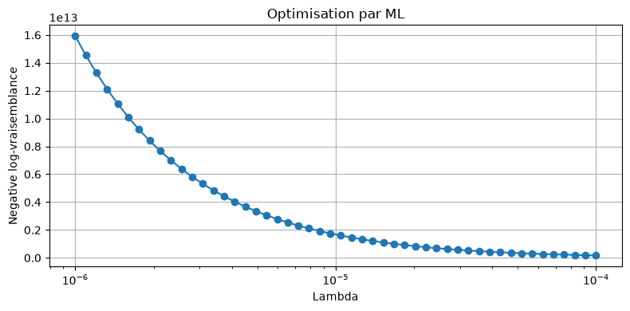

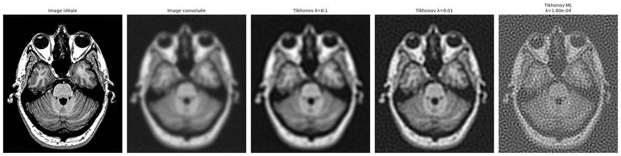

```python
lambda_values = np.logspace(-6, -4, 50)
optimal_lambda, evidences = find_optimal_lambda_ml(mri_noised, D, lambda_values)
print("Lambda optimal trouvé par maximum de vraisemblance :", optimal_lambda)
estimation_ml = tikhonov(mri_noised, D, optimal_lambda)

# --- Figure du GCV ---
plt.figure(figsize=(8, 4))
plt.semilogx(lambda_values, evidences, marker='o')
plt.xlabel("Lambda")
plt.ylabel("Negative log-vraisemblance")
plt.title("Optimisation par ML")
plt.grid(True)
plt.tight_layout()
plt.show()

# --- Figure des images ---
plt.figure(figsize=(20, 10))

# Image idéale
plt.subplot(1, 5, 1)
plt.imshow(mri, cmap='gray')
plt.title("Image idéale", fontsize=10)
plt.axis('off')

# Image convoluée
plt.subplot(1, 5, 2)
plt.imshow(mri_noised, cmap='gray')
plt.title("Image convoluée", fontsize=10)
plt.axis('off')

# Déconvolution Tikhonov lambda = 0.1
plt.subplot(1, 5, 3)
plt.imshow(i_hat, cmap='gray')
plt.title("Tikhonov λ=0.1", fontsize=10)
plt.axis('off')

# Déconvolution Tikhonov lambda = 0.01
plt.subplot(1, 5, 4)
plt.imshow(i_hat2, cmap='gray')
plt.title("Tikhonov λ=0.01", fontsize=10)
plt.axis('off')

# Déconvolution Tikhonov avec ML
plt.subplot(1, 5, 5)
plt.imshow(estimation_ml, cmap='gray')
plt.title(f"Tikhonov ML\nλ={optimal_lambda:.2e}", fontsize=10)
plt.axis('off')

plt.tight_layout()
plt.show()
```

Avec un filtre gaussien plus prononcé pour h et un RSB plus petit, Tikhonov a bien plus de difficulté à restaurer l'image, les lambda choisis par GCV et ML produisent des artefacts à la déconvolution, en prenant un lambda trop petit, la régularisation est inssuffisante et on se rapproche d'une inversion brute, sensible au bruit.

**Normalisation L1 par ADMM**

On utilise ADMM en introduisant une variable auxiliaire v telle que v = x. On a alors :

x = argmin_x(1/2 * ||Hx-y||² + ρ/2 * ||x - (v- u)||²)

v = argmin_z(λ||v||_1 + ρ/2 * ||x - v + u||²

u <- u + (x - v)

La mise à jour en x se résoud en domaine fréquentiel (puisque ||Hx - y||² devient ||D .* X - Y||²)

La mise à jour en v est un soft-thresholding.

u est le multiplicateur d'ADMM (mise à jour par la contrainte x - v = 0)

```python
def soft_thresholding(z, threshold):
  return np.sign(z) * np.maximum(np.abs(z) - threshold, 0)

def admm_deconv_L1(y, D, lambda_, rho=1e2, max_iter=100):
  ny, nx = y.shape

  #Initialisation
  x = np.zeros_like(y)
  v = np.zeros_like(y)
  u = np.zeros_like(y)

  Y = np.fft.fft2(y)
  absD2 = np.abs(D)**2

  for it in range(max_iter):
    #1) x-update en domaine freq
    V_minus_U = v - u
    V_minus_U_fft = np.fft.fft2(V_minus_U)

    numer = np.conj(D)*Y + rho * V_minus_U_fft
    denom = absD2 + rho
    X_fft = numer / denom
    x_new = np.fft.ifft2(X_fft).real

    #2) v-update (soft threshold)
    tmp = x_new + u
    v_new = soft_thresholding(tmp, lambda_/rho)

    #3) u-update
    u_new = u + (x_new - v_new)

    #MAJ
    x, v, u = x_new, v_new, u_new

  return x
```

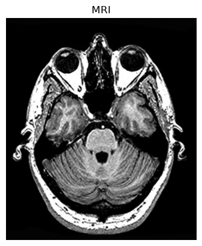

```python
mri = cv2.imread("mri.jpg", cv2.IMREAD_GRAYSCALE)
#convertir en float64
mri = mri.astype(np.float64)
mri = mri / 255.0
plt.imshow(mri, cmap='gray')
plt.title("MRI")
plt.axis("off")
plt.show()
```

```
Variance du bruit 1.4370631600526545e-05
```

```
(np.float64(-0.5), np.float64(377.5), np.float64(439.5), np.float64(-0.5))
```

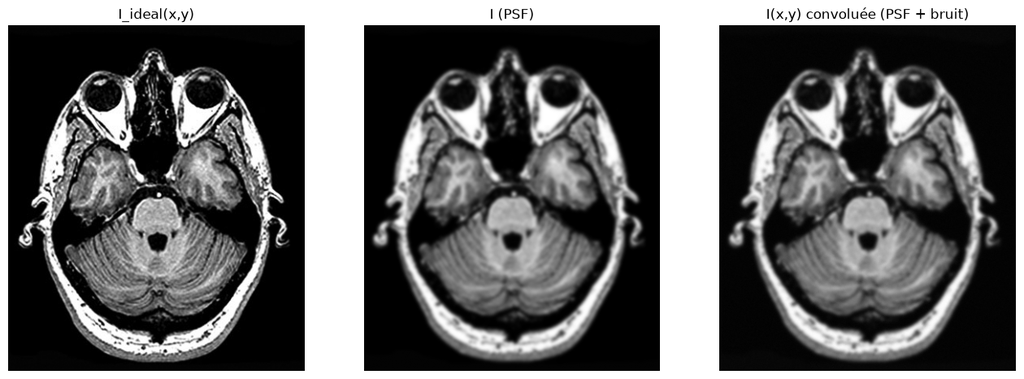

```python
#Créer un filtre gaussien 15x15 avec sigma = 2
h = np.zeros((15, 15))
h[7, 7] = 1
h = gaussian_filter(h, sigma=2)

#Normalisation (somme = 1)
h /= h.sum()


#Padding de h pour qu'il fasse la même taille que x
h_pad = np.pad(h, ((0, mri.shape[0]-h.shape[0]),(0,mri.shape[1]-h.shape[1])), 'constant')

#Roll de h (circshift)
h_roll = np.roll(h_pad, -h.shape[0]//2, axis=0)
h_roll = np.roll(h_roll, -h.shape[1]//2, axis=1)

#H = np.fft.fft2(h_roll)

#Valeurs propres de HBCCB
D = np.fft.fft2(h_roll, s=mri.shape)

X = np.fft.fft2(mri)

conv_X = D * X

mri_conv = np.real(np.fft.ifft2(conv_X))

#Bruiter

mri_noised, noise_variance = gen_noised(mri_conv,40)
print("Variance du bruit", noise_variance)

plt.figure(figsize=(16, 8))
plt.subplot(1, 3, 1)
plt.imshow(mri, cmap='gray')
plt.title("I_ideal(x,y)")
plt.axis("off")

plt.subplot(1, 3, 2)
plt.imshow(mri_conv, cmap='gray')
plt.title("I (PSF)")
plt.axis("off")

plt.subplot(1, 3, 3)
plt.imshow(mri_noised, cmap='gray')
plt.title("I(x,y) convoluée (PSF + bruit)")
plt.axis("off")
```

```
Lambda optimal trouvé par GCV : 0.0002811768697974231
```

```
Lambda optimal trouvé par maximum de vraisemblance : 0.0001
```

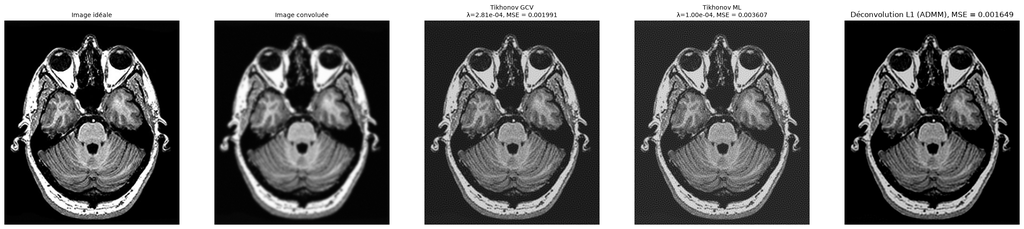

```python
#GCV Tikhonov
lambda_values = np.logspace(-6, 6, 50)
optimal_lambda_gcv, gcv_values = find_optimal_lambda_gcv(mri_noised, D, lambda_values)
print("Lambda optimal trouvé par GCV :", optimal_lambda_gcv)
estimation_GCV = tikhonov(mri_noised, D, optimal_lambda_gcv)

#ML Tikhonov
lambda_values = np.logspace(-6, -4, 50)
optimal_lambda_ml, evidences = find_optimal_lambda_ml(mri_noised, D, lambda_values)
print("Lambda optimal trouvé par maximum de vraisemblance :", optimal_lambda_ml)
estimation_ml = tikhonov(mri_noised, D, optimal_lambda_ml)

# Lancement ADMM L1
x_recon = admm_deconv_L1(mri_noised, D, lambda_=0.01, rho=1, max_iter=300)

# --- Figure des images ---
plt.figure(figsize=(30, 15))

# Image idéale
plt.subplot(1, 5, 1)
plt.imshow(mri, cmap='gray')
plt.title("Image idéale", fontsize=10)
plt.axis('off')

# Image convoluée
plt.subplot(1, 5, 2)
plt.imshow(mri_noised, cmap='gray')
plt.title("Image convoluée", fontsize=10)
plt.axis('off')

# Déconvolution Tikhonov avec GCV
mse, _ = compute_mse_psnr(estimation_GCV, mri)
plt.subplot(1, 5, 3)
plt.imshow(estimation_GCV, cmap='gray')
plt.title(f"Tikhonov GCV\nλ={optimal_lambda_gcv:.2e}, MSE = {mse:2f}", fontsize=10)
plt.axis('off')

# Déconvolution Tikhonov avec ML
mse, _ = compute_mse_psnr(estimation_ml, mri)
plt.subplot(1, 5, 4)
plt.imshow(estimation_ml, cmap='gray')
plt.title(f"Tikhonov ML\nλ={optimal_lambda_ml:.2e}, MSE = {mse:2f}", fontsize=10)
plt.axis('off')

#Deconvolution avec ADMM L1
mse, _ = compute_mse_psnr(x_recon, mri)
plt.subplot(1, 5, 5)
plt.imshow(x_recon, cmap='gray')
plt.title(f"Déconvolution L1 (ADMM), MSE = {mse:2f}")
plt.axis('off')
plt.show()
```

La normalisation L1 est adaptée aux images sparse, or notre image n'est pas sparse dans l'espace des pixels, mais elle sera sparse dans le domaine des ondelettes. On pourrait appliquer une transformée en ondelettes discretes sur l'image pour passer dans l'espace des ondelettes et appliquer ADMM

La L1 favorise des solutions avec beaucoup de valeurs nulles ou proches de 0 (sparses). Cela peut conduire à une perte de détails (dans notre cas d'image IRM, des détails anatomiques), voire des discontinuités non naturelles dans l'image. C'est pour cela qu'on observe un effet "cartoon" dans certaines zones de l'image deconvoluée L1.

Tikhonov a tendance a lisser excessivement les détails, ce que l'on veut éviter pour ne pas lisser les transitions franches ou discontinuités typiques d'une image médicale. L1 / ADMM est davantage apte à préserver les contours, ce qui est mieux adapté dans notre cas d'image médicale.

**Question 4**

J'ai tenté d'utiliser l'implémentation fournie par https://github.com/cszn/DPIR mais les auteurs ne fournissent pas de fichier env.yml ou requirements.txt, j'ai quand même tenté d'installer toutes les dépendances automatiquement avec pipreqs mais même après cela, un grand nombre de fonctions utilisées sont obsolètes et les auteurs ne fournissent pas d'informations concernant les versions des dépendances à utiliser pour permettre de reproduire les résultats